# Fuga_de_Clientes

Laura Piñeros

Febrero 2022

## Estudio descriptivo de datos sobre Fuga de Clientes

```r
#Ruta de Funciones
setwd('C:/Users/Laura/Desktop/UCM/Documentacion2/Tarea')

#cargamos las funciones
source('Funciones_R.R')

#Leer los datos training de Fuga de Clientes
datos <- readRDS("C:/Users/Laura/Desktop/UCM/Documentacion2/Tarea/FugaClientes_Training.RDS")

#cargamos librerias
paquetes(c('questionr','psych','car','corrplot','ggplot2',"gridExtra",'kableExtra','dplyr','DMwR2'))
```

Se presenta la siguiente tabla con la información detallada de cada uno de los campos del dataset.

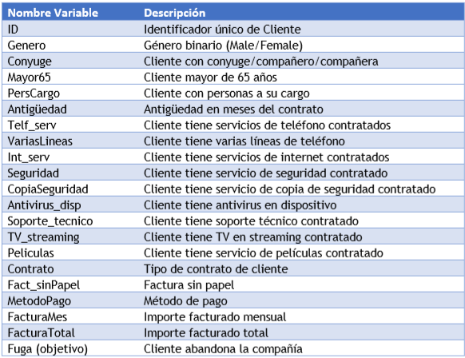

A continuación se comprobarán y se análizarán los tipos de variables, los valores fuera de rango, se definirán variables nominales, Outliers y Missings.

```r
str(datos)
```

```
## 'data.frame':    6353 obs. of  21 variables:
##  $ ID             : Factor w/ 6353 levels "0002-ORFBO","0003-MKNFE",..: 4858 3587 2338 4997 5879 5915 911 4316 5063 4102 ...
##  $ Genero         : Factor w/ 2 levels "Female","Male": 1 2 2 NA 1 1 2 1 NA 2 ...
##  $ Mayor65        : Factor w/ 2 levels "0","1": 1 1 1 1 1 1 1 1 1 1 ...
##  $ Conyuge        : Factor w/ 2 levels "No","Yes": 2 1 1 1 1 1 1 1 2 1 ...
##  $ PersCargo      : Factor w/ 2 levels "No","Yes": 1 1 1 1 1 1 2 1 1 2 ...
##  $ Antig.fc.edad  : num  1 34 2 45 NA 8 22 10 28 62 ...
##  $ Telf_serv      : Factor w/ 2 levels "No","Yes": 1 2 2 1 2 2 2 1 2 2 ...
##  $ VariasLineas   : Factor w/ 2 levels "No","Yes": 1 1 1 1 1 2 2 1 2 1 ...
##  $ Int_serv       : Factor w/ 3 levels "DSL","Fiber optic",..: 1 1 1 1 2 2 2 NA 2 1 ...
##  $ Seguridad      : Factor w/ 2 levels "No","Yes": 1 2 2 2 1 1 1 2 1 2 ...
##  $ CopiaSeguridad : Factor w/ 2 levels "No","Yes": 2 1 2 1 1 1 2 1 1 2 ...
##  $ Antivirus_disp : Factor w/ 2 levels "No","Yes": 1 2 1 2 1 2 1 1 2 1 ...
##  $ Soporte_tecnico: Factor w/ 2 levels "No","Yes": 1 1 1 2 1 1 1 1 2 1 ...
##  $ TV_streaming   : Factor w/ 2 levels "No","Yes": 1 1 1 1 1 2 2 1 2 1 ...
##  $ Peliculas      : Factor w/ 2 levels "No","Yes": 1 1 1 1 1 2 1 1 2 1 ...
##  $ Contrato       : Factor w/ 3 levels "Month-to-month",..: 1 2 1 2 1 1 1 1 1 NA ...
##  $ Fact_sinPapel  : Factor w/ 2 levels "No","Yes": 2 1 2 1 2 2 2 1 2 1 ...
##  $ MetodoPago     : Factor w/ 4 levels "Bank transfer (automatic)",..: NA 4 4 NA 3 NA 2 4 3 NA ...
##  $ FacturaMes     : num  NA NA 53.9 42.3 70.7 ...
##  $ FacturaTotal   : num  29.9 1889.5 108.2 1840.8 151.7 ...
##  $ Fuga           : Factor w/ 2 levels "0","1": 1 1 2 1 2 2 1 1 2 1 ...
```

#Note que: - Tenemos 6353 registros y 21 variables - la mayoría de las variables son de tipo nominales - La variable Mayor65 y Fuga son de tipo nominales(Dicotómicas) - Las variables tienen el tipo correcto de datos. - Cambiamos nombre de la variable Antiguedad - Transformamos ID como caracter(Si la dejamos como factor nos puede traer problemas para el modelo ) - Nuestro modelo consumirá $k-1$ parámetros siendo $k$ el número de niveles del factor.

```r
#Transformación de variables
datos$ID <- as.character(datos$ID)
names(datos)[6]<-"Antiguedad"
names(datos)
```

```
##  [1] "ID"              "Genero"          "Mayor65"         "Conyuge"
##  [5] "PersCargo"       "Antiguedad"      "Telf_serv"       "VariasLineas"
##  [9] "Int_serv"        "Seguridad"       "CopiaSeguridad"  "Antivirus_disp"
## [13] "Soporte_tecnico" "TV_streaming"    "Peliculas"       "Contrato"
## [17] "Fact_sinPapel"   "MetodoPago"      "FacturaMes"      "FacturaTotal"
## [21] "Fuga"
```

```r
str(datos)
```

```
## 'data.frame':    6353 obs. of  21 variables:
##  $ ID             : chr  "7590-VHVEG" "5575-GNVDE" "3668-QPYBK" "7795-CFOCW" ...
##  $ Genero         : Factor w/ 2 levels "Female","Male": 1 2 2 NA 1 1 2 1 NA 2 ...
##  $ Mayor65        : Factor w/ 2 levels "0","1": 1 1 1 1 1 1 1 1 1 1 ...
##  $ Conyuge        : Factor w/ 2 levels "No","Yes": 2 1 1 1 1 1 1 1 2 1 ...
##  $ PersCargo      : Factor w/ 2 levels "No","Yes": 1 1 1 1 1 1 2 1 1 2 ...
##  $ Antiguedad     : num  1 34 2 45 NA 8 22 10 28 62 ...
##  $ Telf_serv      : Factor w/ 2 levels "No","Yes": 1 2 2 1 2 2 2 1 2 2 ...
##  $ VariasLineas   : Factor w/ 2 levels "No","Yes": 1 1 1 1 1 2 2 1 2 1 ...
##  $ Int_serv       : Factor w/ 3 levels "DSL","Fiber optic",..: 1 1 1 1 2 2 2 NA 2 1 ...
##  $ Seguridad      : Factor w/ 2 levels "No","Yes": 1 2 2 2 1 1 1 2 1 2 ...
##  $ CopiaSeguridad : Factor w/ 2 levels "No","Yes": 2 1 2 1 1 1 2 1 1 2 ...
##  $ Antivirus_disp : Factor w/ 2 levels "No","Yes": 1 2 1 2 1 2 1 1 2 1 ...
##  $ Soporte_tecnico: Factor w/ 2 levels "No","Yes": 1 1 1 2 1 1 1 1 2 1 ...
##  $ TV_streaming   : Factor w/ 2 levels "No","Yes": 1 1 1 1 1 2 2 1 2 1 ...
##  $ Peliculas      : Factor w/ 2 levels "No","Yes": 1 1 1 1 1 2 1 1 2 1 ...
##  $ Contrato       : Factor w/ 3 levels "Month-to-month",..: 1 2 1 2 1 1 1 1 1 NA ...
##  $ Fact_sinPapel  : Factor w/ 2 levels "No","Yes": 2 1 2 1 2 2 2 1 2 1 ...
##  $ MetodoPago     : Factor w/ 4 levels "Bank transfer (automatic)",..: NA 4 4 NA 3 NA 2 4 3 NA ...
##  $ FacturaMes     : num  NA NA 53.9 42.3 70.7 ...
##  $ FacturaTotal   : num  29.9 1889.5 108.2 1840.8 151.7 ...
##  $ Fuga           : Factor w/ 2 levels "0","1": 1 1 2 1 2 2 1 1 2 1 ...
```

```r
#Número de valores diferentes para las variables continuas
sapply(Filter(is.numeric, datos),function(x) length(unique(x)))
```

```
##   Antiguedad   FacturaMes FacturaTotal
##           74         1523         5924
```

```r
#Distribución de las variables
summary(datos)
```

```
##       ID               Genero     Mayor65     Conyuge    PersCargo
##  Length:6353        Female:2963   0   :5045   No :3287   No :4439
##  Class :character   Male  :3038   1   : 956   Yes:3066   Yes:1914
##  Mode  :character   NA's  : 352   NA's: 352
##
##
##
##
##    Antiguedad    Telf_serv   VariasLineas        Int_serv    Seguridad
##  Min.   : 0.00   No  : 605   No :3687     DSL        :2122   No :4532
##  1st Qu.: 9.00   Yes :5656   Yes:2666     Fiber optic:2702   Yes:1821
##  Median :29.00   NA's:  92                No         :1339
##  Mean   :32.38                            NA's       : 190
##  3rd Qu.:55.00
##  Max.   :72.00
##  NA's   :394
##  CopiaSeguridad Antivirus_disp Soporte_tecnico TV_streaming Peliculas
##  No :4180       No :4180       No :4509        No :3936     No :3902
##  Yes:2173       Yes:2173       Yes:1844        Yes:2417     Yes:2451
##
##
##
##
##
##            Contrato    Fact_sinPapel                     MetodoPago
##  Month-to-month:3285   No  :2483     Bank transfer (automatic):1283
##  One year      :1261   Yes :3609     Credit card (automatic)  :1290
##  Two year      :1413   NA's: 261     Electronic check         :1972
##  NA's          : 394                 Mailed check             :1336
##                                      NA's                     : 472
##
##
##    FacturaMes      FacturaTotal    Fuga
##  Min.   : 18.25   Min.   :  18.8   0:4667
##  1st Qu.: 35.55   1st Qu.: 394.5   1:1686
##  Median : 70.30   Median :1384.2
##  Mean   : 64.68   Mean   :2268.7
##  3rd Qu.: 89.80   3rd Qu.:3781.5
##  Max.   :118.75   Max.   :8672.5
##  NA's   :394      NA's   :11
```

```r
# Ver el reparto de las categorías de las variables cualitativas
questionr::freq(datos$MetodoPago)
```

|  | n | % | val% |
| --- | --- | --- | --- |
| Bank transfer (automatic) | 1283 | 20.2 | 21.8 |
| Credit card (automatic) | 1290 | 20.3 | 21.9 |
| Electronic check | 1972 | 31.0 | 33.5 |
| Mailed check | 1336 | 21.0 | 22.7 |
| NA | 472 | 7.4 | NA |

```r
questionr::freq(datos$Contrato)
```

|  | n | % | val% |
| --- | --- | --- | --- |
| Month-to-month | 3285 | 51.7 | 55.1 |
| One year | 1261 | 19.8 | 21.2 |
| Two year | 1413 | 22.2 | 23.7 |
| NA | 394 | 6.2 | NA |

```r
#Describe variables numéricas
psych::describe(Filter(is.numeric, datos))
```

|  | vars | n | mean | sd | median | trimmed | mad | min | max | range | skew | kurtosis | se |
| --- | --- | --- | --- | --- | --- | --- | --- | --- | --- | --- | --- | --- | --- |
| Antiguedad | 1 | 5959 | 32.38077 | 24.54041 | 29.000 | 31.44223 | 32.6172 | 0.00 | 72.00 | 72.00 | 0.2403836 | -1.3850451 | 0.3179034 |
| FacturaMes | 2 | 5959 | 64.67837 | 30.01342 | 70.300 | 64.87309 | 35.5824 | 18.25 | 118.75 | 100.50 | -0.2195563 | -1.2530702 | 0.3888023 |
| FacturaTotal | 3 | 6342 | 2268.72715 | 2258.84302 | 1384.175 | 1954.72065 | 1801.2849 | 18.80 | 8672.45 | 8653.65 | 0.9674546 | -0.2153574 | 28.3643563 |

##Visualización del dataset

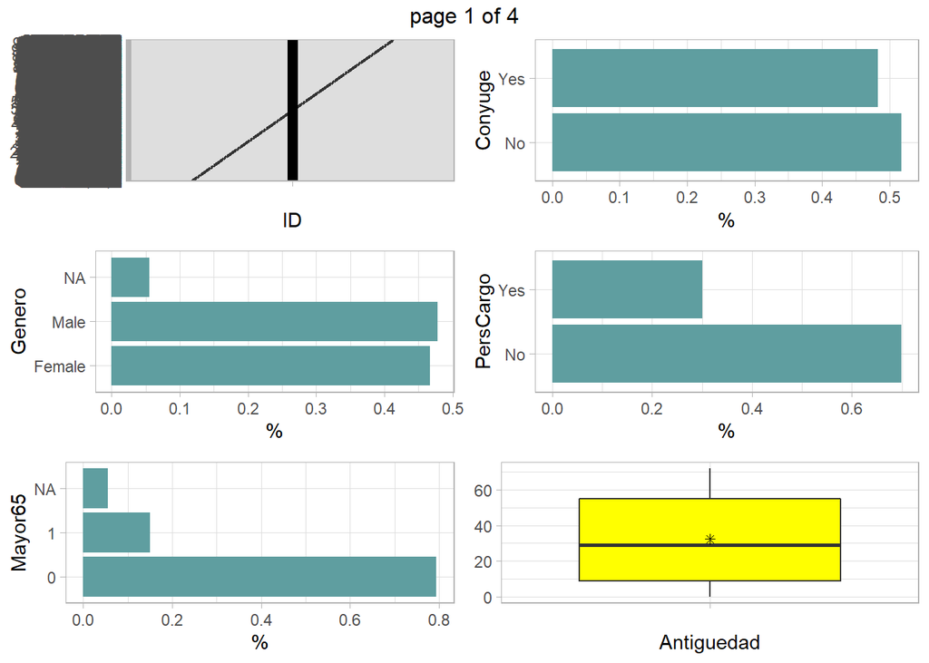

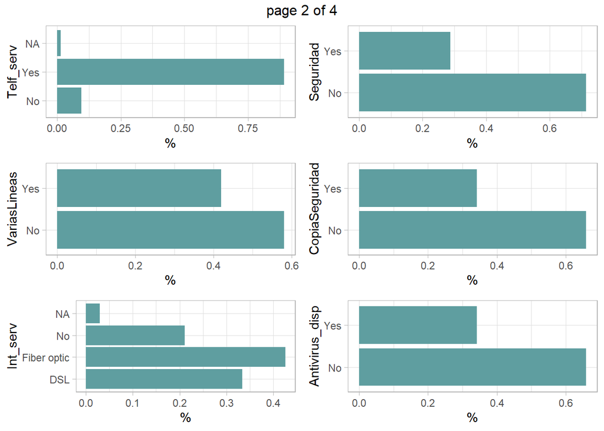

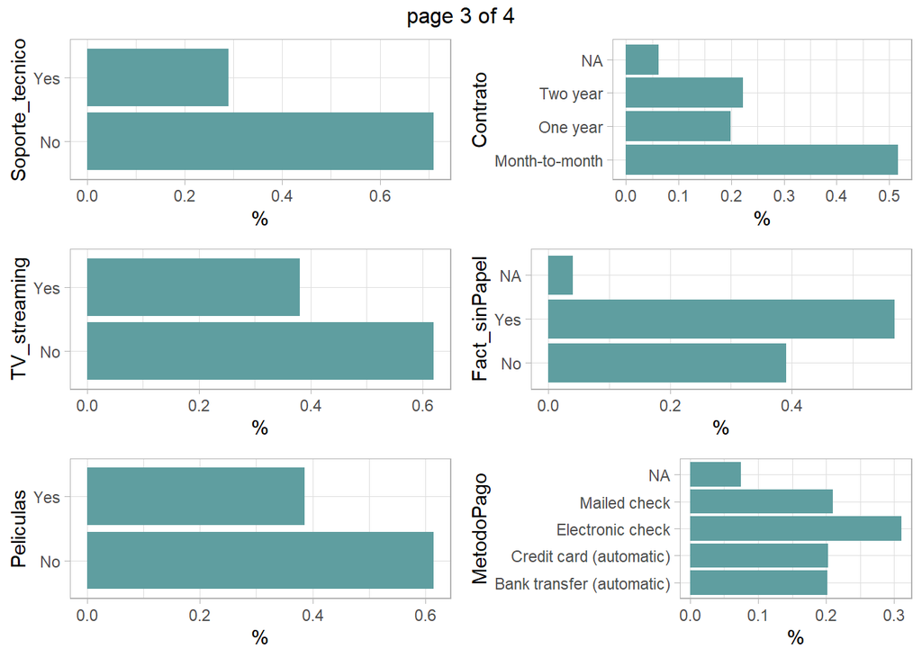

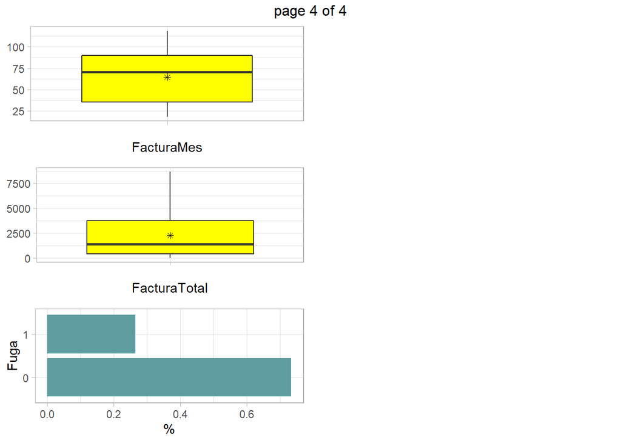

```r
# Inspección gráfica inicial
listaGraf <- dfplot_box(datos) #Boxplots variables numéricas
listaHist<-dfplot_his(datos) #Histogramas variables categóricas

# para presentar una rejilla de graficos a nuestro gusto
gridExtra::marrangeGrob(listaGraf, nrow = 3, ncol = 2)
```

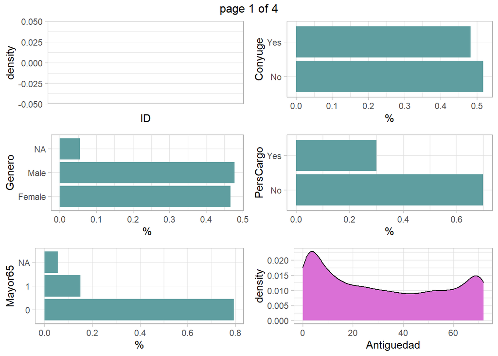

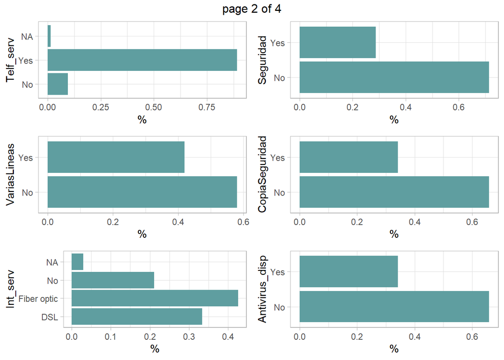

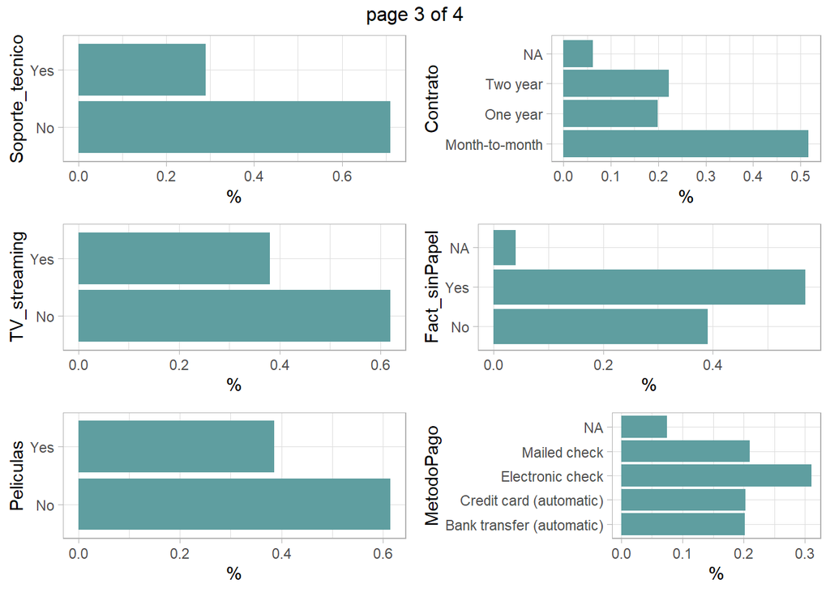

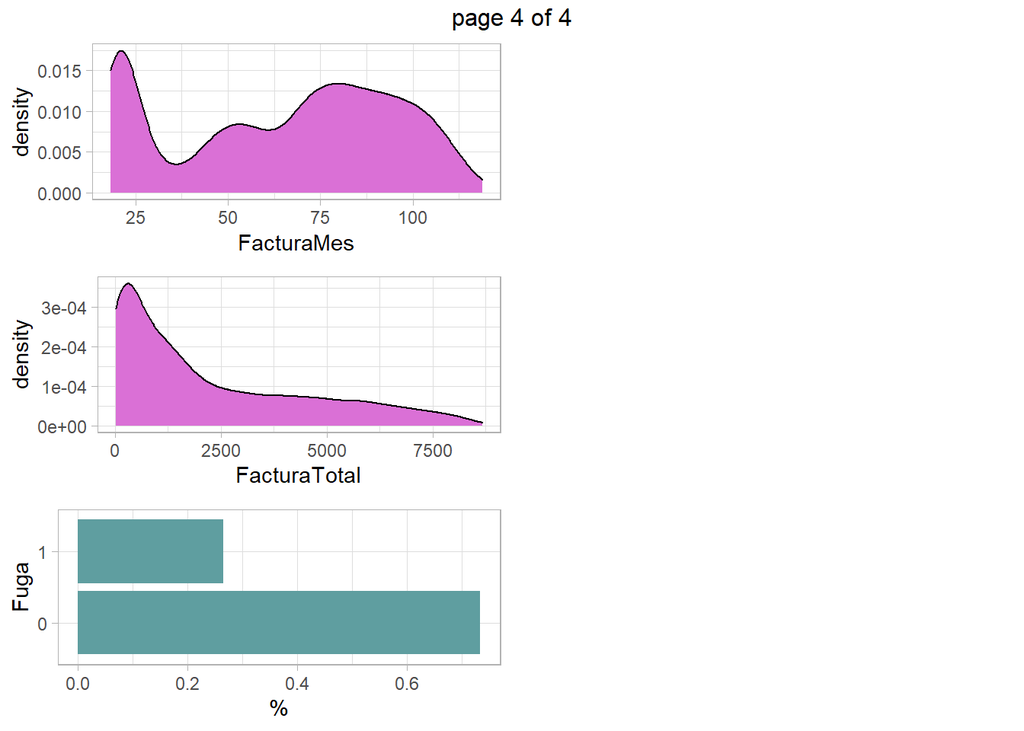

```r
gridExtra::marrangeGrob(listaHist, nrow = 3, ncol = 2)
```

Una vez estudiados los datos y libres de errores, podemos trabajar con el archivo de predictores, teniendo en cuenta que la asimetría será un factor importante para nuestro estudio.

##Gestión de outliers y Missing A continuación presentamos, separación de variables objetivo, ya que no es habitual trabajar con ellas. Así mismo, el conjunto de predictores en input, y tomamos como variable Objetivo Fuga de tipo nominal.

```r
#separación variables objetivo
#conjunto de predictores input
#Los atípicos y los missings se gestionan sólo de las input
#varObjCont<-datos$Beneficio#varaible objetivo continua
varObjBin<-datos$Fuga#variable objetivo binaria (la sacas del dataframe)
input<-as.data.frame(datos[,-(21)])#generas dataframe sin esas variables
input$ID<-as.character(datos$ID)#para realizar comprobaciones
```

##Valores atípicos

Sabemos que los valores atípicos no son demasiado frecuentes y en efecto deben ser poco frecuentes para considerarlos atípicos, llevamos a cabo un conteo de los valores que se consideran extremos según un consenso de dos criterios distintos. En primer lugar, se distingue variable simétrica o posiblemente no, para aplicar *media + 3 sd* ó *mediana + 8 mad*, respectivamente. Recordamos en este punto que todas las medidas de dispersión basadas en la mediana o cuartiles son muy poco sensibles a la presencia de asimetría en la distribución, siendo por ello más fiables en este caso. Por otro lado, aplicamos el clásico criterio del boxplot umbrales en *cuartil1 - 3IQR* y *cuartil3+ 3IQR*.

```r
## Proporción de Atípicos
# Cuento el porcentaje de atípicos de cada variable.
# Si son muchos, elimino esas
# variables en la siguiente línea de código
sapply(Filter(is.numeric, input),
       function(x) atipicosAmissing(x)[[2]])/nrow(input)
```

```
##   Antiguedad   FacturaMes FacturaTotal
##            0            0            0
```

```r
#devuleve una lista de los atipicos convertidos a missing con el argumento 1
#argumento 2 de tipo informativo , pues me dice que proporción hay (incidencia)



# data.frame para el % de atipicos por variable
t<-data.frame(sort(
  round(sapply(Filter(
    is.numeric, input),function(nOut) atipicosAmissing(
      nOut)[[2]])/nrow(input)*100,3), decreasing = T))
names(t)<-"% Outliers por variable"

# Formato normal
t
```

|  | % Outliers por variable |
| --- | --- |
| Antiguedad | 0 |
| FacturaMes | 0 |
| FacturaTotal | 0 |

Ya que la incidencia es muy baja, practicamente nula pasamos a tratar los Valores perdidos.